# Assessment

by Lau Wen Jun

1. A. Automation
   - QA1.
   - QA2.
2. B. Research
   - QB1.
   - QB2.
   - QB3.
     - Data Preparation and Processing
     - Anomaly Detection Algorithms
     - Trends and Outliers
       - Transaction Volume
       - Transaction Value
     - Additional Insights

## A. Automation

### QA1

In my previous role, I automated data extraction, transformation, and reporting for education statistics dashboards. The objective was to reduce manual effort, improve data accuracy, and accelerate report generation for decision-making.

**Tools**

- **SQL & AWS Athena:** Used for efficient data querying and aggregation from large datasets.
- **Python (Pandas, NumPy):** Automated data transformation.
- **Tableau** Enabled real-time dashboard updates and automated visualizations.
- **Power BI (with Power Query & DAX) & Power Automate:** Scheduled automated dashboard

**Time Saved**

- Manual reporting time reduced from 10 hours per week to under 30 minutes.
- Automated data updates eliminated errors and ensured real-time access to key performance metrics.

### QA2

**Data Consistency Issues:** Different sources had inconsistent formats and missing values.

**Solution:** Implemented automated data cleaning scripts in Python using Pandas to standardize formats and handle missing data.

**Large Dataset Processing Delays:** Queries on AWS Athena were slow for large datasets.

**Solution:** Optimized SQL queries, used partitioning and indexing, and leveraged aggregated summary tables to improve efficiency.

**Integration with Power BI & Scheduled Reports:** Automating the Power BI refresh and report distribution required a reliable setup.

**Solution:** Used Power Automate to trigger refreshes and schedule reports, ensuring stakeholders received up-to-date insights without manual intervention.

## B. Research

### QB1

**Thesis of the Research**

This research project aimed to predict students' cumulative grade point averages (CGPAs) with high accuracy by integrating demographic, psychological, and behavioral factors using advanced machine learning techniques. The study sought to bridge existing gaps in educational analytics by analyzing how various factors contribute to academic success and identifying students at risk of poor performance.

**Methodology**

To develop an effective prediction model, we employed a machine learning-based approach that involved:

- ***Feature Engineering:*** Raw student data was transformed into meaningful variables to capture key academic and behavioral patterns.
- ***Model Selection:*** We implemented multiple machine learning models, including XGBoost, Random Forest, and Logistic Regression.
- ***Stacking Ensemble Learning:*** To enhance predictive performance, we combined multiple models into an ensemble framework, leveraging the strengths of different algorithms.
- ***Hyperparameter Tuning & Class Imbalance Handling:*** Optimized model performance by fine-tuning parameters and addressing data imbalance issues.
- ***Explainable AI (XAI):*** SHAP (SHapley Additive exPlanations) was used to interpret model predictions, ensuring transparency and allowing educators to understand which factors most influence academic success.

This methodological approach was chosen because machine learning models outperform traditional statistical methods in handling complex, high-dimensional educational data. The integration of explainable AI also made the predictions interpretable and actionable for stakeholders in the education sector.

**Conclusion & Key Findings** The study successfully developed a scalable and highly accurate prediction model for CGPA forecasting. The results demonstrated that:

- Psychological and behavioral factors (e.g., study habits, engagement levels) were just as significant as demographic factors in predicting academic outcomes.
- Machine learning models, particularly ensemble-based approaches, significantly improved prediction accuracy compared to standalone models.
- SHAP-based explainability enabled institutions to identify at-risk students early and tailor interventions accordingly.

This project highlights the transformative potential of AI in education, demonstrating how predictive analytics can support data-driven decision-making to foster academic success. The scalable prediction pipeline developed in this research offers educational institutions a valuable tool for proactively improving student outcomes.

### QB2

To ensure reliability and accuracy:

**1. Cross-Validation:** Prevented overfitting by evaluating model performance across multiple data splits.

**2. Train-Test Split with Stratified Sampling:** Maintained class balance in training and testing sets.

**3. Hyperparameter Tuning:** Optimized model performance using Grid Search and Bayesian Optimization.

**4. Class Imbalance Handling (SMOTE):** Prevented bias toward majority-class students.

**5. Multi-Metric Evaluation:** Used Accuracy, Precision, Recall, F1-Score, and ROC-AUC for performance assessment.

**6. SHAP-Based Explainability:** Ensured interpretability and detected potential biases.

These validation measures guaranteed robust, reproducible, and unbiased findings suitable for real-world educational applications.

### QB3

#### B3.1. Data Preparation and Processing

The dataset, containing payment transaction data, was first imported and cleaned to ensure accuracy in analysis. The column names were stripped of any extra spaces, and the "Period" column was converted into a datetime format for proper time-based analysis. To facilitate meaningful insights, the data was then aggregated by "Period" and "Instrument Type", summing all numerical values to obtain total transaction volumes and values per instrument type for each time period. This process ensures that trends and anomalies can be effectively analyzed across different payment instruments over time. Finally, the unique instrument types were extracted, allowing for further segmentation and visualization of transaction patterns across different payment methods.

```python
import pandas as pd
import numpy as np
import matplotlib.pyplot as plt
import plotly.graph_objects as go
from sklearn.ensemble import IsolationForest
from sklearn.svm import OneClassSVM
from sklearn.cluster import DBSCAN, KMeans
from sklearn.mixture import GaussianMixture
from sklearn.neighbors import LocalOutlierFactor
from scipy.stats import zscore
from statsmodels.tsa.seasonal import STL
import warnings
```

```python
# Suppress warnings
warnings.filterwarnings('ignore')

# Load the dataset
file_path = r"C:\Users\Jun\Downloads\Payment Data Set.csv"
df = pd.read_csv(file_path)

# Clean column names
df.columns = df.columns.str.strip()

# Convert "Period" to datetime format
df["Period"] = pd.to_datetime(df["Period"], format="%Y%m%d")

# Aggregate by Period and Instrument Type
df_instrument_trend = df.groupby(["Period", "Instrument Type"]).sum(numeric_only=True).reset_index()

# Get the unique instrument types
instrument_types = df_instrument_trend["Instrument Type"].unique()
```

### B3.2. Anomaly Detection Algorithms

```python
# Define anomaly detection methods
anomaly_methods = ['ZScore', 'IQR', 'STL_Loess', 'IsoForest', 'LOF', 'DBSCAN','KMeans','GaussianMixture', 'OneClassSVM']

# Function to detect anomalies
def detect_anomalies(df, column):
    results = {method: np.zeros(len(df)) for method in anomaly_methods}

    # Z-Score method
    z_scores = np.abs(zscore(df[column]))
    results['ZScore'] = np.where(z_scores > 1.96, -1, 1)

    # IQR method
    Q1 = df[column].quantile(0.25)
    Q3 = df[column].quantile(0.75)
    IQR = Q3 - Q1
    lower_bound = Q1 - 1.5 * IQR
    upper_bound = Q3 + 1.5 * IQR
    results['IQR'] = np.where((df[column] < lower_bound) | (df[column] > upper_bound), -1, 1)

    # Isolation Forest
    iso_forest = IsolationForest(contamination=0.2, random_state=42)
    results['IsoForest'] = iso_forest.fit_predict(df[[column]])

    # Local Outlier Factor
    lof = LocalOutlierFactor(n_neighbors=5, contamination=0.2)
    results['LOF'] = lof.fit_predict(df[[column]])

    # DBSCAN
    dbscan = DBSCAN(eps=0.5, min_samples=100)
    results['DBSCAN'] = np.where(dbscan.fit_predict(df[[column]]) == -1, -1, 1)

    # KMeans
    kmeans = KMeans(n_clusters=3, random_state=42, n_init=10)
    clusters = kmeans.fit_predict(df[[column]])
    results['KMeans'] = np.where(clusters == np.argmax(np.bincount(clusters)), 1, -1)

    # # Gaussian Mixture Model
    gmm = GaussianMixture(n_components=3, random_state=42)
    gmm.fit(df[[column]])
    gmm_probs = gmm.predict_proba(df[[column]])
    results['GaussianMixture'] = np.where(gmm_probs[:, 0] < 0.05, -1, 1)

    # # One-Class SVM
    oc_svm = OneClassSVM(nu=0.95, kernel="rbf", gamma=0.1)
    results['OneClassSVM'] = oc_svm.fit_predict(df[[column]])

    # Combine results
    df_results = pd.DataFrame(results)
    df_results["Anomaly Count"] = (df_results == -1).sum(axis=1)
    df_results["Final Anomaly"] = np.where(df_results["Anomaly Count"] >= 4 , -1, 1)

    return df_results["Final Anomaly"], df_results

# Apply anomaly detection for each instrument type on both Volume and Value
anomaly_results = {}
all_anomaly_counts = {}

for instrument in df_instrument_trend["Instrument Type"].unique():
    subset = df_instrument_trend[df_instrument_trend["Instrument Type"] == instrument].copy()

    # Detect anomalies for Volume
    subset["Volume Anomaly"], volume_results = detect_anomalies(subset, "Volume (Million)")

    # Detect anomalies for Value
    subset["Value Anomaly"], value_results = detect_anomalies(subset, "Value (RM Million)")

    anomaly_results[instrument] = subset

    # Store anomaly counts for both Volume and Value
    volume_anomalies = volume_results.iloc[:, :-2].apply(lambda x: (x == -1).sum())
    value_anomalies = value_results.iloc[:, :-2].apply(lambda x: (x == -1).sum())
    all_anomaly_counts[instrument] = {
        "Volume Anomalies": volume_anomalies,
        "Value Anomalies": value_anomalies
    }

# Combine all results
final_anomaly_data = pd.concat(anomaly_results.values())

# Print consolidated anomaly counts at the end
print("Anomaly Counts Per Method Across All Instrument Types:\n")
for instrument, anomaly_data in all_anomaly_counts.items():
    print(f"Instrument Type: {instrument}")
    print("Volume Anomalies:")
    print(anomaly_data["Volume Anomalies"])
    print("Value Anomalies:")
    print(anomaly_data["Value Anomalies"])
    print("-" * 50)
```

```
Anomaly Counts Per Method Across All Instrument Types:

Instrument Type: Charge Card
Volume Anomalies:
ZScore              1
IQR                 0
STL_Loess           0
IsoForest          15
LOF                15
DBSCAN             73
KMeans             43
GaussianMixture    47
OneClassSVM        71
dtype: int64
Value Anomalies:
ZScore              0
IQR                 0
STL_Loess           0
IsoForest          15
LOF                15
DBSCAN             73
KMeans             46
GaussianMixture    36
OneClassSVM        62
dtype: int64
--------------------------------------------------
Instrument Type: Credit Card
Volume Anomalies:
ZScore              3
IQR                 0
STL_Loess           0
IsoForest          15
LOF                14
DBSCAN             73
KMeans             38
GaussianMixture    53
OneClassSVM        70
dtype: int64
Value Anomalies:
ZScore              2
```

[output cut: 43 more lines]

```
GaussianMixture    48
OneClassSVM        70
dtype: int64
Value Anomalies:
ZScore              4
IQR                 1
STL_Loess           0
IsoForest          15
LOF                15
DBSCAN             73
KMeans             38
GaussianMixture    14
OneClassSVM        16
dtype: int64
--------------------------------------------------
```

### B3.3. Trends and Outliers

#### B3.3.1. Transaction Volume

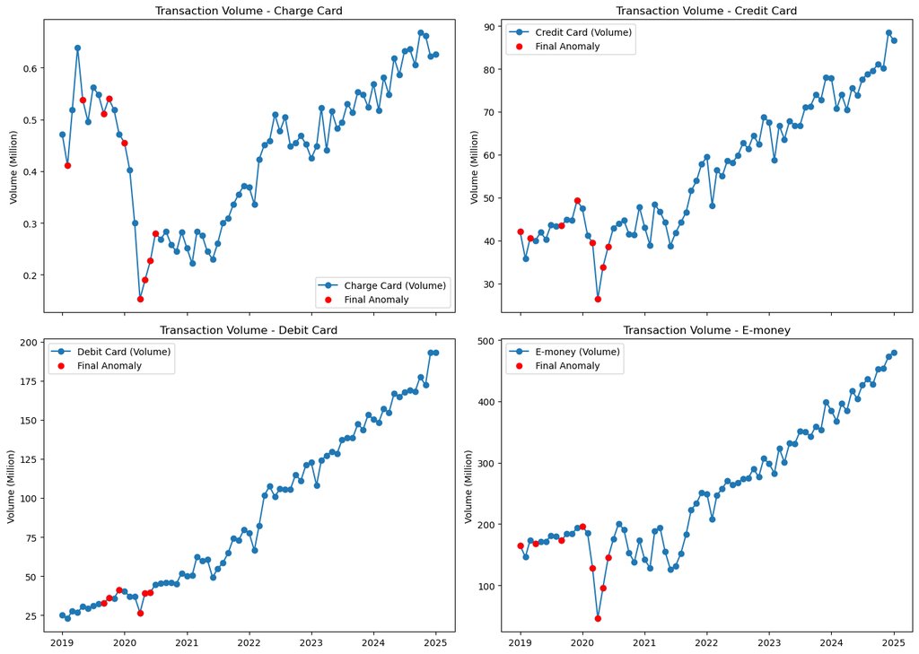

```python
# Plot transaction volume with final anomaly detection
fig, axes = plt.subplots(2, 2, figsize=(14, 10), sharex=True)

for i, instrument in enumerate(instrument_types):
    row, col = divmod(i, 2)
    subset = final_anomaly_data[final_anomaly_data["Instrument Type"] == instrument]

    # Plot normal transaction volume
    axes[row, col].plot(subset["Period"], subset["Volume (Million)"], marker="o", linestyle="-", label=f"{instrument} (Volume)")

    # Highlight final anomalies in red
    anomalies = subset[subset["Volume Anomaly"] == -1]
    axes[row, col].scatter(anomalies["Period"], anomalies["Volume (Million)"], color='red', label="Final Anomaly", zorder=3)

    axes[row, col].set_title(f"Transaction Volume - {instrument}")
    axes[row, col].set_ylabel("Volume (Million)")
    axes[row, col].legend()

plt.tight_layout()
plt.show()
```

#### B3.3.2. Transaction Value

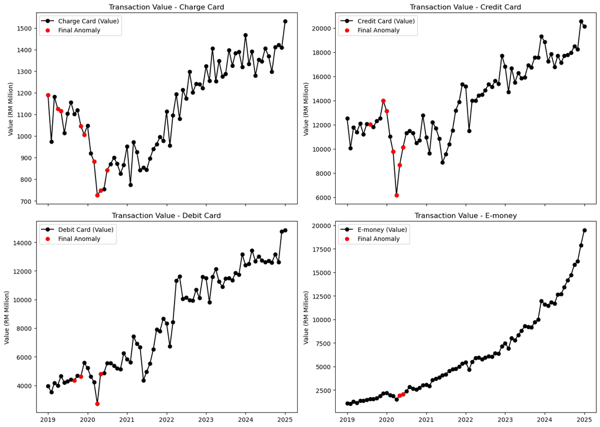

```python
# Plot transaction value with final anomaly detection
fig, axes = plt.subplots(2, 2, figsize=(14, 10), sharex=True)

for i, instrument in enumerate(instrument_types):
    row, col = divmod(i, 2)
    subset = final_anomaly_data[final_anomaly_data["Instrument Type"] == instrument]

    # Plot normal transaction value
    axes[row, col].plot(subset["Period"], subset["Value (RM Million)"], marker="o", linestyle="-", color="black", label=f"{instrument} (Value)")

    # Highlight final anomalies in red
    anomalies = subset[subset["Value Anomaly"] == -1]
    axes[row, col].scatter(anomalies["Period"], anomalies["Value (RM Million)"], color='red', label="Final Anomaly", zorder=3)

    axes[row, col].set_title(f"Transaction Value - {instrument}")
    axes[row, col].set_ylabel("Value (RM Million)")
    axes[row, col].legend()

plt.tight_layout()
plt.show()
```

**Charge Card & Credit Card Transactions:**

- A sharp decline in transaction volume is observed around early 2020, coinciding with COVID-19 restrictions that significantly reduced physical transactions.
- A gradual recovery in volume starts post-2021, indicating a return to normal spending patterns.

Outliers (red dots) detected in early and mid-2020 highlight periods where transaction volumes dropped drastically compared to historical trends.

**Debit Card Transactions:**

- Steady volume growth is observed throughout the period, with small dips in early 2020 but no drastic declines.
- Outliers in early 2020 suggest temporary transaction disruptions, but overall, debit card usage remained relatively stable compared to credit-based transactions.

**E-Money Transactions:**

- Consistent and exponential growth in volume is evident, reflecting the shift towards digital payments.
- A sharp drop in early 2020, flagged as an anomaly, suggests temporary economic disruptions, but the trend recovers quickly.
- Fewer anomalies in recent years, confirming a stable and growing adoption of digital payment methods.

#### 3.3.2. Transaction Value Trends & Outliers

**Charge Card & Credit Card Transactions:**

- A significant drop in transaction value occurs in early 2020, reflecting a decline in higher-value purchases during COVID-19 restrictions.
- Transaction values recover gradually from 2021 onward, indicating a return to pre-pandemic spending behaviors.
- Outliers in early and mid-2020 confirm periods where the value of transactions dipped more than expected.

**Debit Card Transactions:**

- Transaction value follows a steady and exponential growth pattern, reinforcing the increasing adoption of digital payments.
- An anomaly is detected in early 2020, likely due to temporary disruptions, but value transactions recover quickly.
- Unlike card-based transactions, E-Money transactions exhibit fewer value-based outliers in recent years, confirming strong consumer adoption.

### B3.4. Additional Insights

**1. COVID-19 Had a Significant Impact on Transactions**

- Anomalies confirm that credit and charge card transactions saw a sharp decline during early 2020, while e-money transactions rebounded faster.
- Debit Card transactions remained more stable, suggesting a shift to essential spending.

**2. E-Money Transactions Show the Most Stable Growth**

- Despite a temporary drop in early 2020, e-money transactions quickly rebounded, showing strong adoption of digital payments.
- This trend aligns with Malaysia’s push for a cashless economy.